# Линейная алгебра. Практическая работа №12

[🌀 Home Page](https://olgabelitskaya.github.io/README.html) [📓 Previous](https://github.com/OlgaBelitskaya/linear_algebra_practice/blob/master/work1_11.ipynb) [📓 Next](https://github.com/OlgaBelitskaya/linear_algebra_practice/blob/master/work1_13.ipynb)

### Программные средства

[LaTeX. Mathematics](https://en.wikibooks.org/wiki/LaTeX/Mathematics) [Sage. Linear Algebra](http://doc.sagemath.org/html/en/tutorial/tour_linalg.html) [Numpy. Quickstart tutorial](https://docs.scipy.org/doc/numpy/user/quickstart.html#linear-algebra)

[R Functions - Tutorialspoint](https://www.tutorialspoint.com/r/r_functions.htm) [Quick-R: User-Defined Functions](https://www.statmethods.net/management/userfunctions.html)

### Конспекты

[АЛГЕБРА И ГЕОМЕТРИЯ ДЛЯ СТУДЕНТОВ-ФИЗИКОВ](http://math.phys.msu.ru/data/24/Algebra_and_geometry.pdf)

[АНАЛИТИЧЕСКАЯ ГЕОМЕТРИЯ](http://ffmgu.ru/images/1/16/%D0%9E%D0%B2%D1%87%D0%B8%D0%BD%D0%BD%D0%B8%D0%BA%D0%BE%D0%B2._%D0%9B%D0%B5%D0%BA%D1%86%D0%B8%D0%B8_%D0%90%D0%93._2009.pdf)

[Computational Mathematics with SageMath](http://dl.lateralis.org/public/sagebook/sagebook-ba6596d.pdf)

[Introduction to Symbolic Computation](http://homepages.math.uic.edu/~jan/mcs320/mcs320.pdf)

# Линейные пространства. Линейные преобразования и операторы

## 1. Линейные пространства

*Линейное пространство* $\mathbb{L(C)}$ над числовым полем $\mathbb{C}$ — это множество векторов $\mathbb{L}$, в котором введены две операции:

- сложение элементов $x + y, \ \forall x, y \in \mathbb{L}$
- умножение элемента на число $\alpha \cdot x, \forall \alpha \in \mathbb{C}, \forall x \in \mathbb{L}$

причем выполнены следующие аксиомы:

$(1) \ \forall x, y \in \mathbb{L} : x + y = y + x$ (коммутативность сложения);

$(2) \ \forall x, y, z \in \mathbb{L} : x + (y + z) = x + (y + z)$ (ассоциативность сложения);

$(3) \ \exists 0 \in \mathbb{L} \ \forall x \in \mathbb{L} : x + 0 = x$ (существование нулевого вектора);

$(4) \ \forall x \in \mathbb{L} \ \exists -x \in \mathbb{L} : x + (-x) = 0$ (существование противоположного вектора);

$(5) \ \forall x \in \mathbb{L} : 1 \cdot x = x$ (существование единичного вектора);

$(6) \ \forall \alpha, \beta \in \mathbb{C}, \forall x \in \mathbb{L} : (\alpha \cdot \beta) \cdot x = \alpha \cdot (\beta \cdot x)$;

$(7) \ \forall \alpha \in \mathbb{C}, \forall x, y \in \mathbb{L} : \alpha \cdot (x + y) = \alpha \cdot x + \alpha \cdot y$ (дистрибутивность-1);

$(8) \ \forall \alpha, \beta \in \mathbb{C}, \forall x \in \mathbb{L} : (\alpha + \beta) \cdot x = \alpha \cdot x + \beta \cdot x$ (дистрибутивность-2).

Простейшие свойства линейных пространств:

1) нулевой элемент единственен;

2) единичный элемент единственен;

3) $\forall x, y, z \in \mathbb{L}: x + z = y + z \implies x = y$ и т.д.

*Примеры*

Декартова прямоугольная система координат

$\overrightarrow{0}\{0;0;0\}$ - нулевой вектор

$\overrightarrow{i}\{1;0;0\}, \overrightarrow{j}\{0;1;0\}, \overrightarrow{k}\{0;0;1\}$ — единичные направляющие векторы координатных осей

$\overrightarrow{v}\{x;y;z\} = x \cdot \overrightarrow{i} + y \cdot \overrightarrow{j} + z \cdot \overrightarrow{k}$

$\{x;y;z\}$ - {абсцисса; ордината; аппликата}

$\overrightarrow{v_{xy}}\{x;y;0\}$ - проекция $\overrightarrow{v}\{x;y;z\}$ на плоскость $Oxy$

В системах кординат углы между векторами $\overrightarrow{i}, \overrightarrow{j}, \overrightarrow{k}$ могут быть не прямыми, длины векторов могут быть $\neq 1$.

Цилиндрическая система координат

$\begin{cases} x = r \cos \varphi \\ y = r \sin \varphi \\ z = h \end{cases}; \ \begin{cases} r = \sqrt{x^2 + y^2} \\ \cos \varphi = \frac{x}{\sqrt{x^2 + y^2}} \\ \sin \varphi = \frac{y}{\sqrt{x^2 + y^2}} \\ h = z \end{cases}$

Географические координаты (вариант сферических)

$\begin{cases} x = r \cos \varphi \cos \vartheta \\ y = r \sin \varphi \cos \vartheta \\ z = r \sin \vartheta \end{cases}$

*Векторы* коллинеарны, если они лежат на параллельных прямых.

Коллинеарные векторы с общим началом лежат на одной прямой.

$\overrightarrow{a}, \overrightarrow{b}$ - коллинеарны $\iff \exists \ \alpha, \beta \neq 0$ одновременно: $\alpha \overrightarrow{a} + \beta \overrightarrow{b} = \overrightarrow{0}$

Базис на плоскости — упорядоченный набор двух неколлинеарных векторов.

Векторы компланарны, если они лежат в параллельных плоскостях.

Компланарные векторы с общим началом лежат в одной плоскости.

$\overrightarrow{a}, \overrightarrow{b}, \overrightarrow{c}$ - компланарны $\iff \exists \ \alpha, \beta, \gamma \neq 0$ одновременно: $\alpha \overrightarrow{a} + \beta \overrightarrow{b} + \gamma \overrightarrow{c}= \overrightarrow{0}$

Базис в пространстве — упорядоченный набор трех некомпланарных векторов.

*Линейная комбинация* векторов

$\alpha_1 \overrightarrow{x_1} + \alpha_2 \overrightarrow{x_2} + ... + \alpha_n \overrightarrow{x_n}$

Линейная комбинация называется тривиальной, если все ее коэффициенты равны нулю.

$0 \overrightarrow{x_1} + 0 \overrightarrow{x_2} + ... + 0 \overrightarrow{x_n} = \overrightarrow{0}$

Векторы *линейно независимы*, если нулевому вектору равна только их тривиальная линейная комбинация.

Векторы линейно зависимы $\iff$ их смешанное произведение равно нулю.

$\overrightarrow{x}\{x_1;x_2;x_3\} \cdot \overrightarrow{y}\{y_1;y_2;y_3\} \cdot \overrightarrow{z}\{z_1;z_2;z_3\} = \begin{vmatrix} x_1 & x_2 & x_3 \\ y_1 & y_2 & y_3 \\ z_1 & z_2 & z_3 \end{vmatrix} = 0$

*Базис* линейного пространства - линейно независимый упорядоченный набор векторов,

позволяющий любой вектор пространства представить в виде линейной комбинации этого набора (разложение по базису),

причем коэффициенты в этом случае - координаты вектора.

Разложение вектора по базису единственно.

*Размерность* линейного пространства = числу векторов базиса.

Большее, чем размерность, количество векторов пространства всегда линейно зависимо.

```python
from sage.plot.plot3d.plot3d import axes
l=['i','j','k','v','2i','2i+3j','3j','2k']
s=6*[[0,0,0]]+[[2,0,0],[2,3,0]]
k=[[1,0,0],[0,1,0],[0,0,1],[2,3,2],
   [2,0,0],[2,3,0],[2,3,0],[2,3,2]]
w=[1,1,1,3,2,2,2,2]
o=[.9,.9,.9,.6,.3,.3,.3,.3]
c=['#3636ff','#ff3636','#36ff36','#363636',
   '#3636ff','#ff36ff','#ff3636','#36ff36']
v=sum([arrow3d(s[i],k[i],color=c[i],width=w[i],
               opacity=o[i],mesh=True)
       for i in [0..7]])
t=sum([text3d(l[i],[(s[i][j]+k[i][j])/2 for j in [0..2]],
              color=c[i]).rotate((1.5,1.5,1.5),pi/12)
       for i in [0..7]])
(v+t+axes(3,.5,color='black')).show()
```

[interactive chart not shown]

```python
i,j,k=vector(SR,[1,0,0]),vector(SR,[0,1,0]),vector(SR,[0,0,1]);
v=vector(SR,[2,3,2]); 2*i+3*j+2*k==v
```

```
True
```

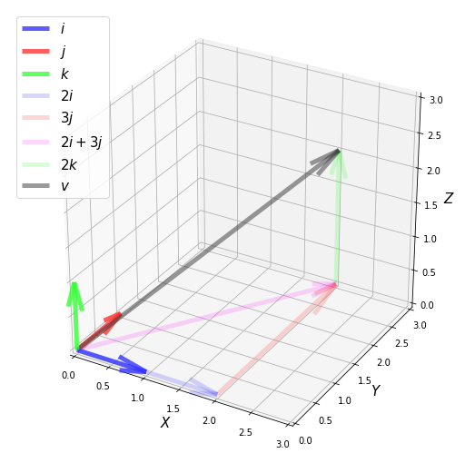

```python
import numpy,sympy,sympy.vector,pylab
sympy.init_printing(use_unicode=True)
from mpl_toolkits.mplot3d import Axes3D
fig=pylab.figure(figsize=(9,9))
ax=fig.add_subplot(111,projection='3d')
c=['#3636ff','#ff3636','#36ff36','#3636ff',
   '#ff3636','#ff36ff','#36ff36','#363636']
x0,y0,z0=[0,0,0,0,2,0,2,0],[0,0,0,0,0,0,3,0],[0,0,0,0,0,0,0,0]
x,y,z=[1,0,0,2,0,2,0,2],[0,1,0,0,3,3,0,3],[0,0,1,0,0,0,2,2]
a=[.8,.8,.8,.2,.2,.2,.2,.5]; alr=[.4,.4,.4,.2,.2,.1,.2,.1]
l=[r'$i$',r'$j$',r'$k$',r'$2i$',r'$3j$',r'$2i+3j$',r'$2k$',r'$v$']
[ax.quiver(x0[i],y0[i],z0[i],x[i],y[i],z[i],colors=c[i],
           lw=5,arrow_length_ratio=alr[i],alpha=a[i],label=l[i])
 for i in range(8)]
ax.set_xlabel(r'$X$',fontsize=15)
ax.set_ylabel(r'$Y$',fontsize=15)
ax.set_zlabel(r'$Z$',fontsize=15)
ax.set_xlim([0,3]); ax.set_ylim([0,3]); ax.set_zlim([0,3])
ax.legend(fontsize=15,loc=2); pylab.show()
```

```python
se=sympy.vector.CoordSys3D('se')
v=2*se.i+3*se.j+2*se.k; display(v)
[i,j,k]=[numpy.array([1,0,0]),numpy.array([0,1,0]),
         numpy.array([0,0,1])]
v=numpy.array([2,3,2]); 2*i+3*j+2*k==v
```

$\displaystyle (2)\mathbf{\hat{i}_{se}} + (3)\mathbf{\hat{j}_{se}} + (2)\mathbf{\hat{k}_{se}}$

```
array([ True,  True,  True])
```

```python
%%r
i<-c(1,0,0); j<-c(0,1,0); k<-c(0,0,1);
v<-c(2,3,2); v==2*i+3*j+2*k
```

```
[1] TRUE TRUE TRUE
```

## 2. Линейные преобразования

В пространстве заданы два произвольных базиса $\overrightarrow{e_1}, \overrightarrow{e_2}, ..., \overrightarrow{e_n}$ и $\overrightarrow{f_1}, \overrightarrow{f_2}, ..., \overrightarrow{f_n}$:

$\begin {cases} \overrightarrow{f_1} = c_{11}\overrightarrow{e_1} + c_{12}\overrightarrow{e_2} + ... + c_{1n}\overrightarrow{e_n} \\ \overrightarrow{f_2} = c_{21}\overrightarrow{e_1} + c_{22}\overrightarrow{e_2} + ... + c_{2n} \overrightarrow{e_n} \\ ... \\ \overrightarrow{f_n} = c_{n1}\overrightarrow{e_1} + c_{n2}\overrightarrow{e_2} + ... + c_{nn} \overrightarrow{e_n} \end{cases}$

Коэффициенты уравнений - матрица перехода $C$ от первого базиса ко второму.

Тогда матрица перехода от координат вектора относительно первого базиса к координатам относительно второго равна $(C^{-1})^T$.

```python
cc=" ".join(list('c_%d%d'%(i,j)
    for i in (1..2) for j in (1..2)))
C=matrix(SR,2,var(cc))
for el in [C,C.det(),C.inverse(),
           (C^(-1)).transpose()]:
    pretty_print(el)
cc=" ".join(list('c_%d%d'%(i,j)
    for i in (1..3) for j in (1..3)))
C=matrix(SR,3,var(cc))
ee=" ".join(list('e_%d%d'%(i,j)
    for i in (1..3) for j in (1..3)))
E=matrix(SR,3,var(ee))
ff=" ".join(list('f_%d%d'%(i,j)
    for i in (1..3) for j in (1..3)))
F=matrix(SR,3,var(ff))
pretty_print(C*E-F)
```

$$\newcommand{\Bold}[1]{\mathbf{#1}}\left(\begin{array}{rr}
c_{11} & c_{12} \\
c_{21} & c_{22}
\end{array}\right)$$

$$\newcommand{\Bold}[1]{\mathbf{#1}}-c_{12} c_{21} + c_{11} c_{22}$$

$$\newcommand{\Bold}[1]{\mathbf{#1}}\left(\begin{array}{rr}
\frac{1}{c_{11}} - \frac{c_{12} c_{21}}{c_{11}^{2} {\left(\frac{c_{12} c_{21}}{c_{11}} - c_{22}\right)}} & \frac{c_{12}}{c_{11} {\left(\frac{c_{12} c_{21}}{c_{11}} - c_{22}\right)}} \\
\frac{c_{21}}{c_{11} {\left(\frac{c_{12} c_{21}}{c_{11}} - c_{22}\right)}} & -\frac{1}{\frac{c_{12} c_{21}}{c_{11}} - c_{22}}
\end{array}\right)$$

$$\newcommand{\Bold}[1]{\mathbf{#1}}\left(\begin{array}{rr}
\frac{1}{c_{11}} - \frac{c_{12} c_{21}}{c_{11}^{2} {\left(\frac{c_{12} c_{21}}{c_{11}} - c_{22}\right)}} & \frac{c_{21}}{c_{11} {\left(\frac{c_{12} c_{21}}{c_{11}} - c_{22}\right)}} \\
\frac{c_{12}}{c_{11} {\left(\frac{c_{12} c_{21}}{c_{11}} - c_{22}\right)}} & -\frac{1}{\frac{c_{12} c_{21}}{c_{11}} - c_{22}}
\end{array}\right)$$

$$\newcommand{\Bold}[1]{\mathbf{#1}}\left(\begin{array}{rrr}
c_{11} e_{11} + c_{12} e_{21} + c_{13} e_{31} - f_{11} & c_{11} e_{12} + c_{12} e_{22} + c_{13} e_{32} - f_{12} & c_{11} e_{13} + c_{12} e_{23} + c_{13} e_{33} - f_{13} \\
c_{21} e_{11} + c_{22} e_{21} + c_{23} e_{31} - f_{21} & c_{21} e_{12} + c_{22} e_{22} + c_{23} e_{32} - f_{22} & c_{21} e_{13} + c_{22} e_{23} + c_{23} e_{33} - f_{23} \\
c_{31} e_{11} + c_{32} e_{21} + c_{33} e_{31} - f_{31} & c_{31} e_{12} + c_{32} e_{22} + c_{33} e_{32} - f_{32} & c_{31} e_{13} + c_{32} e_{23} + c_{33} e_{33} - f_{33}
\end{array}\right)$$

```python
cc=" ".join(list('c_%d%d' %(i,j)
    for i in [1,2] for j in [1,2]))
C=sympy.Matrix(int(2),int(2),sympy.symbols(cc))
for el in [C,C.det(),C.inv(),
           (C^(-1)).transpose()]:
    display(el,15*'=-=')
NC=numpy.matrix([[1,2],[3,4]])
for el in [NC,numpy.linalg.inv(NC),
           numpy.linalg.inv(NC).T]:
    print(el)
```

$\displaystyle \left[\begin{matrix}c_{11} & c_{12}\\c_{21} & c_{22}\end{matrix}\right]$

```
'=-==-==-==-==-==-==-==-==-==-==-==-==-==-==-='
```

$\displaystyle c_{11} c_{22} - c_{12} c_{21}$

```
'=-==-==-==-==-==-==-==-==-==-==-==-==-==-==-='
```

$\displaystyle \left[\begin{matrix}\frac{c_{22}}{c_{11} c_{22} - c_{12} c_{21}} & - \frac{c_{12}}{c_{11} c_{22} - c_{12} c_{21}}\\- \frac{c_{21}}{c_{11} c_{22} - c_{12} c_{21}} & \frac{c_{11}}{c_{11} c_{22} - c_{12} c_{21}}\end{matrix}\right]$

```
'=-==-==-==-==-==-==-==-==-==-==-==-==-==-==-='
```

$\displaystyle \left[\begin{matrix}\frac{c_{22}}{c_{11} c_{22} - c_{12} c_{21}} & - \frac{c_{21}}{c_{11} c_{22} - c_{12} c_{21}}\\- \frac{c_{12}}{c_{11} c_{22} - c_{12} c_{21}} & \frac{c_{11}}{c_{11} c_{22} - c_{12} c_{21}}\end{matrix}\right]$

```
'=-==-==-==-==-==-==-==-==-==-==-==-==-==-==-='
```

```
[[1 2]
 [3 4]]
[[-2.   1. ]
 [ 1.5 -0.5]]
[[-2.   1.5]
 [ 1.  -0.5]]
```

```python
%%r
C<-matrix(c(1,2,3,4),2,2,byrow=T)
list(C,solve(C),t(solve(C)))
```

```
[[1]]
     [,1] [,2]
[1,]    1    2
[2,]    3    4

[[2]]
     [,1] [,2]
[1,] -2.0  1.0
[2,]  1.5 -0.5

[[3]]
     [,1] [,2]
[1,]   -2  1.5
[2,]    1 -0.5
```

Пример решения задачи с матрицей перехода

$C: (\mathfrak{e_1},\mathfrak{e_2},\mathfrak{e_3}) \to (\mathfrak{f_1},\mathfrak{f_2},\mathfrak{f_3}) \\ \begin{cases} \mathfrak{e_1} \{1;3;3\} \\ \mathfrak{e_2} \{-3;-3;-2\} \\ \mathfrak{e_3} \{-2;2;3\} \end {cases} \to \begin {cases} \mathfrak{f_1} \{1;4;-2\} \\ \mathfrak{f_2} \{-2;-1;2\} \\ \mathfrak{f_3} \{4;1;-2\} \end{cases}$

$\mathfrak{e} \{-19;7;16\} \to \mathfrak{f} \{x;y;z\}?$

```python
E=matrix(SR,3,[1,3,3,-3,-3,-2,-2,2,3])
F=matrix(SR,3,[1,4,-2,-2,-1,2,4,1,-2])
e=matrix(SR,3,[-19,7,16])
C=E.solve_left(F); f=(C^(-1)).transpose()*e
for el in [C,C*E==F,f]: pretty_print(el)
```

$$\newcommand{\Bold}[1]{\mathbf{#1}}\left(\begin{array}{rrr}
-\frac{71}{2} & -\frac{49}{2} & \frac{37}{2} \\
\frac{27}{2} & \frac{19}{2} & -\frac{13}{2} \\
-\frac{17}{2} & -\frac{13}{2} & \frac{7}{2}
\end{array}\right)$$

$$\newcommand{\Bold}[1]{\mathbf{#1}}\mathrm{True}$$

$$\newcommand{\Bold}[1]{\mathbf{#1}}\left(\begin{array}{r}
-\frac{115}{6} \\
-\frac{351}{4} \\
-\frac{685}{12}
\end{array}\right)$$

```python
E=sympy.Matrix(int(3),int(3),
               [1,3,3,-3,-3,-2,-2,2,3])
F=sympy.Matrix(int(3),int(3),
               [1,4,-2,-2,-1,2,4,1,-2])
e=sympy.Matrix(int(3),int(1),[-19,7,16])
C=F*E^(-1); f=(C^(-1)).transpose()*e
for el in [C,C*E==F,f]: display(el)
E=numpy.matrix([[1,3,3],[-3,-3,-2],[-2,2,3]])
F=numpy.matrix([[1,4,-2],[-2,-1,2],[4,1,-2]])
C=F*numpy.linalg.inv(E)
e=numpy.matrix([[-19],[7],[16]])
f=numpy.linalg.inv(C).T*e
for el in [C,round(C*E,0)==F,f]: print(el)
```

$\displaystyle \left[\begin{matrix}- \frac{71}{2} & - \frac{49}{2} & \frac{37}{2}\\\frac{27}{2} & \frac{19}{2} & - \frac{13}{2}\\- \frac{17}{2} & - \frac{13}{2} & \frac{7}{2}\end{matrix}\right]$

```
True
```

$\displaystyle \left[\begin{matrix}- \frac{115}{6}\\- \frac{351}{4}\\- \frac{685}{12}\end{matrix}\right]$

```
[[-35.5 -24.5  18.5]
 [ 13.5   9.5  -6.5]
 [ -8.5  -6.5   3.5]]
[[ True  True  True]
 [ True  True  True]
 [ True  True  True]]
[[-19.16666667]
 [-87.75      ]
 [-57.08333333]]
```

```python
%%r
E<-matrix(c(1,3,3,-3,-3,-2,-2,2,3),3,3,byrow=T)
F<-matrix(c(1,4,-2,-2,-1,2,4,1,-2),3,3,byrow=T)
e<-matrix(c(-19,7,16),3,1)
C<-F%*%solve(E); f <- t(solve(C))%*%e
for (el in list(C,round(C%*%E)==F)) {print(el)}
f
```

```
      [,1]  [,2] [,3]
[1,] -35.5 -24.5 18.5
[2,]  13.5   9.5 -6.5
[3,]  -8.5  -6.5  3.5
     [,1] [,2] [,3]
[1,] TRUE TRUE TRUE
[2,] TRUE TRUE TRUE
[3,] TRUE TRUE TRUE
          [,1]
[1,] -19.16667
[2,] -87.75000
[3,] -57.08333
```

## 3. Линейные операторы

Оператор преобразования одного линейного пространства в другое

$A: V \to W$

$\forall x \in V \ \exists y \in W: y = Ax$

Линейный оператор

1) $A(x_1 + x_2) = Ax_1 + Ax_2$

2) $A(\lambda x) = \lambda (Ax)$

Матрица линейного оператора в старом базисе

$A = C^{-1} * \tilde{A} * C$

Матрица линейного оператора в новом базисе

$\tilde{A} = C * A * C^{-1}$

Пример решения задачи с матрицей линейного оператора

$A\mathfrak{e_1=f_1}: \mathfrak{e_1}\{1;3;3\}; \mathfrak{f_1} \{1;4;-2\} \\ A\mathfrak{e_2=f_2}: \mathfrak{e_2}\{-3;-3;-2\}; \mathfrak{f_2} \{-2;-1;2\} \\ A\mathfrak{e_3=f_3}: \mathfrak{e_3}\{-2;2;3\}; \mathfrak{f_3} \{4;1;-2\}$

$A\mathfrak{e=f}: \mathfrak{e}\{-19;7;16\}; \mathfrak{f} \{x;y;z\}?$

```python
a=[[1,3,3,0,0,0,0,0,0],[-3,-3,-2,0,0,0,0,0,0],
   [-2,2,3,0,0,0,0,0,0],[0,0,0,1,3,3,0,0,0],
   [0,0,0,-3,-3,-2,0,0,0],[0,0,0,-2,2,3,0,0,0],
   [0,0,0,0,0,0,1,3,3],[0,0,0,0,0,0,-3,-3,-2],
   [0,0,0,0,0,0,-2,2,3]]
a=matrix(SR,a)
b=matrix(SR,9,[1,-2,4,4,-1,1,-2,2,-2])
A=matrix(SR,3,[x[0] for x in a.solve_right(b)])
e1=matrix(SR,3,[1,3,3]); f1=matrix(SR,3,[1,4,-2])
e2=matrix(SR,3,[-3,-3,-2]); f2=matrix(SR,3,[-2,-1,2])
e3=matrix(SR,3,[-2,2,3]); f3=matrix(SR,3,[4,1,-2])
e=matrix(SR,3,[-19,7,16]); f=A*e
for el in [f,(A*e1==f1,A*e2==f2,A*e3==f3)]:
    pretty_print(el)
```

$$\newcommand{\Bold}[1]{\mathbf{#1}}\left(\begin{array}{r}
15 \\
13 \\
-8
\end{array}\right)$$

$$\newcommand{\Bold}[1]{\mathbf{#1}}\left(\mathrm{True}, \mathrm{True}, \mathrm{True}\right)$$

```python
A11,A12,A13,A21,A22,A23,A31,A32,A33=\
sympy.symbols('A11,A12,A13,A21,A22,A23,A31,A32,A33')
a=[[1,3,3,0,0,0,0,0,0,1],[-3,-3,-2,0,0,0,0,0,0,-2],
   [-2,2,3,0,0,0,0,0,0,4],[0,0,0,1,3,3,0,0,0,4],
   [0,0,0,-3,-3,-2,0,0,0,-1],[0,0,0,-2,2,3,0,0,0,1],
   [0,0,0,0,0,0,1,3,3,-2],[0,0,0,0,0,0,-3,-3,-2,2],
   [0,0,0,0,0,0,-2,2,3,-2]]
system=sympy.Matrix(a)
A=sympy.solve_linear_system(system,\
A11,A12,A13,A21,A22,A23,A31,A32,A33)
A=sympy.Matrix(int(3),int(3),[A[x]\
for x in [A11,A12,A13,A21,A22,A23,A31,A32,A33]])
e1=sympy.Matrix(int(3),int(1),[1,3,3])
f1=sympy.Matrix(int(3),int(1),[1,4,-2])
e2=sympy.Matrix(int(3),int(1),[-3,-3,-2])
f2=sympy.Matrix(int(3),int(1),[-2,-1,2])
e3=sympy.Matrix(int(3),int(1),[-2,2,3])
f3=sympy.Matrix(int(3),int(1),[4,1,-2])
e=sympy.Matrix(int(3),int(1),[-19,7,16])
f=A*e
for el in [f,(A*e1==f1,A*e2==f2,A*e3==f3)]:
    display(el)
```

$\displaystyle \left[\begin{matrix}15\\13\\-8\end{matrix}\right]$

```
(True, True, True)
```

```python
a=[[1,3,3,0,0,0,0,0,0],[-3,-3,-2,0,0,0,0,0,0],
   [-2,2,3,0,0,0,0,0,0],[0,0,0,1,3,3,0,0,0],
   [0,0,0,-3,-3,-2,0,0,0],[0,0,0,-2,2,3,0,0,0],
   [0,0,0,0,0,0,1,3,3],[0,0,0,0,0,0,-3,-3,-2],
   [0,0,0,0,0,0,-2,2,3]]
a=numpy.matrix(a)
b=numpy.matrix([1,-2,4,4,-1,1,-2,2,-2]).T
A=numpy.matrix(numpy.linalg.solve(a,b)).reshape(3,3)
e1=numpy.matrix([1,3,3]).T; f1=numpy.matrix([1,4,-2]).T
e2=numpy.matrix([-3,-3,-2]).T; f2=numpy.matrix([-2,-1,2]).T
e3=numpy.matrix([-2,2,3]).T; f3=numpy.matrix([4,1,-2]).T
e=numpy.matrix([-19,7,16]).T; f=A*e
ar=[round(A*e1)==f1,round(A*e2)==f2,round(A*e3)==f3]
for el in [f,numpy.array(ar).reshape(3,3)]: print(el)
```

```
[[15.]
 [13.]
 [-8.]]
[[ True  True  True]
 [ True  True  True]
 [ True  True  True]]
```

```python
%%r
a<-matrix(c(1,3,3,0,0,0,0,0,0,
            -3,-3,-2,0,0,0,0,0,0,
            -2,2,3,0,0,0,0,0,0,
            0,0,0,1,3,3,0,0,0,
            0,0,0,-3,-3,-2,0,0,0,
            0,0,0,-2,2,3,0,0,0,
            0,0,0,0,0,0,1,3,3,
            0,0,0,0,0,0,-3,-3,-2,
            0,0,0,0,0,0,-2,2,3),
          9,9,byrow=T)
b<-matrix(c(1,-2,4,4,-1,1,-2,2,-2),9,1)
A<-matrix(solve(a,b),3,3,byrow=T)
e1<-matrix(c(1,3,3),3,1); f1<-matrix(c(1,4,-2),3,1)
e2<-matrix(c(-3,-3,-2),3,1); f2<-matrix(c(-2,-1,2),3,1)
e3<-matrix(c(-2,2,3),3,1); f3<-matrix(c(4,1,-2),3,1)
e<-matrix(c(-19,7,16),3,1); f<-A%*%e
print(c(round(A%*%e1)==f1,
      round(A%*%e2)==f2,
      round(A%*%e3)==f3))
f
```

```
[1] TRUE TRUE TRUE TRUE TRUE TRUE TRUE TRUE TRUE
     [,1]
[1,]   15
[2,]   13
[3,]   -8
```

Пример решения задачи с матрицей перехода и матрицей линейного оператора

$C: (\mathfrak{e_1},\mathfrak{e_2},\mathfrak{e_3}) \to (\mathfrak{f_1},\mathfrak{f_2},\mathfrak{f_3}) \\ \begin{cases} f_1 = e_1+ e_2 + e_3 \\ f_2 = 2 e_1+ 3 e_2 + 4 e_3 \\ f_3 = 3 e_1+ 5 e_2 + 8 e_3 \end{cases}$

$A = \begin{pmatrix} -3 & -4 & -1 \\ 4 & -3 & -3 \\ -3 & 2 & -6 \end{pmatrix} \to \tilde{A} ?$

```python
A=matrix(SR,3,[-3,-4,-1,4,-3,-3,-3,2,-6])
C=matrix(SR,3,[1,1,1,2,3,4,3,5,8])
AT=C*A*C.inverse(); pretty_print(AT)
```

$$\newcommand{\Bold}[1]{\mathbf{#1}}\left(\begin{array}{rrr}
2 & 1 & -2 \\
-23 & 43 & -23 \\
-74 & 116 & -57
\end{array}\right)$$

```python
A=numpy.matrix([-3,-4,-1,4,-3,-3,-3,2,-6]).reshape(3,3)
C=numpy.matrix([1,1,1,2,3,4,3,5,8]).reshape(3,3)
print(C*A*numpy.linalg.inv(C))
A=sympy.Matrix([[-3,-4,-1],[4,-3,-3],[-3,2,-6]])
C=sympy.Matrix([[1,1,1],[2,3,4],[3,5,8]])
C*A*C.inv()
```

```
[[  2.   1.  -2.]
 [-23.  43. -23.]
 [-74. 116. -57.]]
```

$\displaystyle \left[\begin{matrix}2 & 1 & -2\\-23 & 43 & -23\\-74 & 116 & -57\end{matrix}\right]$

```python
%%r
A<-matrix(c(-3,-4,-1,4,-3,-3,-3,2,-6),
          3,3,byrow=T)
C<-matrix(c(1,1,1,2,3,4,3,5,8),
          3,3,byrow=T)
C%*%A%*%t(matrix(solve(C),3,3,byrow=T))
```

```
     [,1] [,2] [,3]
[1,]    2    1   -2
[2,]  -23   43  -23
[3,]  -74  116  -57
```

## 4. Собственные значения и собственные векторы линейного оператора

Собственный ненулевой вектор $\overline{u}\{x;y;z\}$ и соответствующее ему собственное значение $\lambda$ для матрицы $A$

$A \overline{u} = \lambda \overline{u} \iff \begin{pmatrix} a_{11} & a_{12} & a_{13} \\ a_{21} & a_{22} & a_{23} \\ a_{31} & a_{32} & a_{33} \end{pmatrix} * \begin{pmatrix} x \\ y \\ z \end{pmatrix} = \begin{pmatrix} \lambda x \\ \lambda y \\ \lambda z \end{pmatrix} \iff \begin{vmatrix} a_{11}-\lambda & a_{12} & a_{13} \\ a_{21} & a_{22}-\lambda & a_{23} \\ a_{31} & a_{32} & a_{33}-\lambda \end{vmatrix} = 0$

```python
A=matrix(SR,3,[-4,-3,-5,5,4,5,-7,-7,-6])
var('t')
At=matrix([[-4-t,-3,-5],[5,4-t,5],[-7,-7,-6-t]])
for el in [solve(At.det(),t),A.eigenvalues(),
           A.eigenvectors_right()]:
    pretty_print(el)
```

$$\newcommand{\Bold}[1]{\mathbf{#1}}\left[t = 1, t = \left(-1\right), t = \left(-6\right)\right]$$

$$\newcommand{\Bold}[1]{\mathbf{#1}}\left[1, -1, -6\right]$$

$$\newcommand{\Bold}[1]{\mathbf{#1}}\left[\left(1, \left[\left(1,\,0,\,-1\right)\right], 1\right), \left(-1, \left[\left(1,\,-1,\,0\right)\right], 1\right), \left(-6, \left[\left(1,\,-1,\,1\right)\right], 1\right)\right]$$

```python
A=sympy.Matrix([[-4,-3,-5],[5,4,5],[-7,-7,-6]])
t=sympy.symbols('t')
At=sympy.Matrix([[-4-t,-3,-5],[5,4-t,5],[-7,-7,-6-t]])
for el in [sympy.solve(At.det(),t),
           A.eigenvals(),A.eigenvects()]:
    display(el)
```

$\displaystyle \left[ -6, \ -1, \ 1\right]$

$\displaystyle \left\{ -6 : 1, \ -1 : 1, \ 1 : 1\right\}$

$\displaystyle \left[ \left( -6, \ 1, \ \left[ \left[\begin{matrix}1\\-1\\1\end{matrix}\right]\right]\right), \ \left( -1, \ 1, \ \left[ \left[\begin{matrix}-1\\1\\0\end{matrix}\right]\right]\right), \ \left( 1, \ 1, \ \left[ \left[\begin{matrix}-1\\0\\1\end{matrix}\right]\right]\right)\right]$

```python
A=numpy.matrix([-4,-3,-5,5,4,5,-7,-7,-6]).reshape(3,3)
print(numpy.linalg.eigvals(A))
for i in range(3):
    sympy.pprint(round(numpy.linalg.eig(A)[1])[:,i])
```

```
[-6.  1. -1.]
 [[ 1.]
  [-1.]
 [ 1.]]
 [[-1.]
  [ 0.]
 [ 1.]]
 [[-1.]
  [ 1.]
 [ 0.]]
```

```python
%%r
A<-matrix(c(-4,-3,-5,5,4,5,-7,-7,-6),3,3,byrow=T)
print(eigen(A)$values); round(eigen(A)$vectors)
```

```
[1] -6  1 -1
     [,1] [,2] [,3]
[1,]    1   -1   -1
[2,]   -1    0    1
[3,]    1    1    0
```

## 5. Задание.

$1.$ Линейный оператор преобразует векторы следующим образом:

$A\mathfrak{e_1=f_1}: \mathfrak{e_1}\{-2;-2;-3\}; \mathfrak{f_1} \{-1;3;4\} \\ A\mathfrak{e_2=f_2}: \mathfrak{e_2}\{-1;-1;1\}; \mathfrak{f_2} \{1;-1;-3\} \\ A\mathfrak{e_3=f_3}: \mathfrak{e_3}\{2;3;-2\}; \mathfrak{f_3} \{1;4;-2\}$

В какой вектор этот оператор переведет $\mathfrak{e}?$

$A\mathfrak{e=f}: \mathfrak{e}\{-17;-20;-3\}; \mathfrak{f} \{x;y;z\}?$

$2.$ Инициировать случайную матрицу целых чисел,

найти для нее собственные вектора и собственные значения,

используя SageMath, Python, R.